# SSF simulations

Marie Auger-Méthé

2025-11-12

# Goals

1. Use simulations to show that ignoring health and/or fitness proxies can bias selection analysis when using an step selection function.
2. Check that the proposed methodology works.

# General set up

## Load packages

```r
library(terra) # for transforming raster into terra object for plotting
library(tidyterra) # for easy plotting of raster
library(fields) # to simulate data with prioritizr
library(prioritizr) # to simulate Gaussian random fields
library(sf)
library(tidyverse)
library(ggpubr)
library(MuMIn) # for AICc
library(CircStats) # to simulate steps
library(amt) # to fit ssf

#install.packages("glmmTMB",type="source") # If problems with TMB version
library(glmmTMB) # to fit ssf

library(parallel)
n.cores <- detectCores() # Using all of the cores from computer
RNGkind("L'Ecuyer-CMRG") # To set seed with mclapply
```

## Plot set up

```r
# Colour for proxy
proxy.min.col <- "#d73027"
proxy.mid.col <- "#ffffbf"
proxy.max.col <- "#4575b4"
# Size of title/labels
axis.title.size <- rel(1)
axis.label.size <- rel(0.8)
```

# General simulation set up - with a simple example

## Simulate spatial covariates

Simulate a spatial covariate using a Gaussian random field.

First, we will define the size of our study area, and create a base raster.

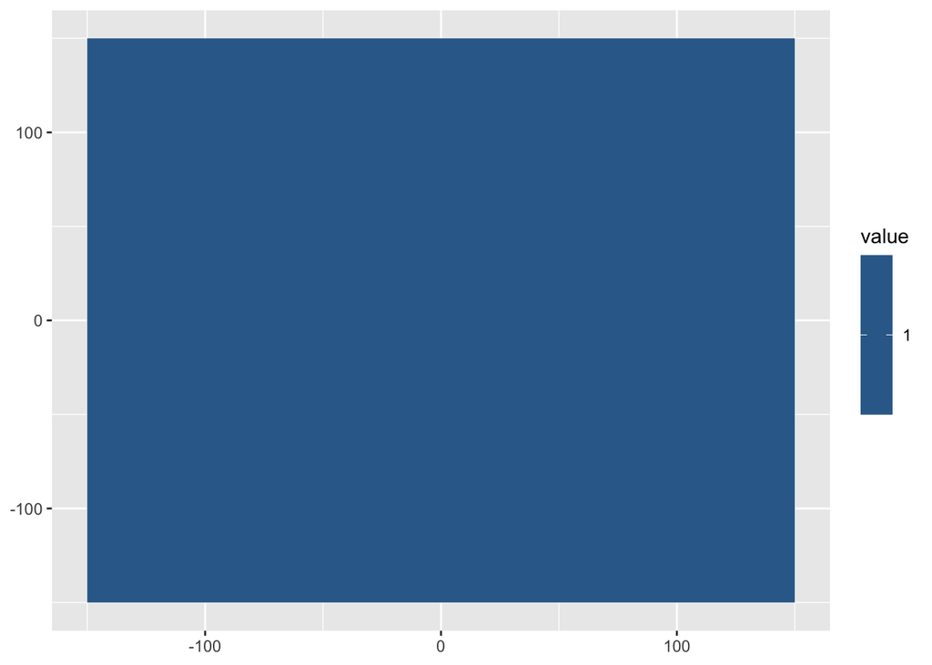

```r
study.area <- terra::rast(
  ncols = 300, nrows = 300,
  xmin = -150, xmax = 150,
  ymin = -150, ymax = 150,
  vals = 1)

ggplot() +
  geom_spatraster(data = study.area)
```

Then, we use the function `simulate_data` from the packages `prioritizr` to simulate the field. The argument `scale` defines the spatial autocorrelation, while `sd` the standard deviation of the data, and `n` is the number of layers. Here, we simulate one covariate named `cov1`.

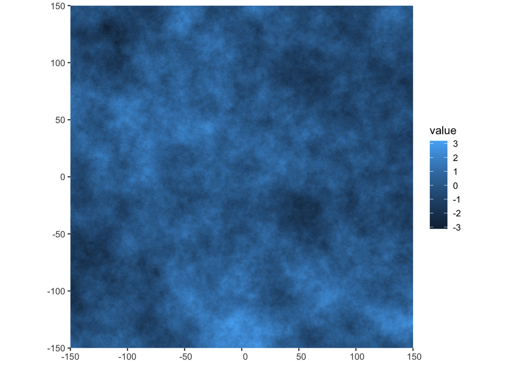

```r
set.seed(1987)
# simulate data using a Gaussian field

cov1 <- simulate_data(study.area, n = 1, scale = 0.9, sd = 0.1)
names(cov1) <- "cov1"

ggplot() +
  geom_spatraster(data = cov1) +
  coord_sf(expand = FALSE)
```

# Function to simulate movement based on a step selection function

Here we define a function that can simulate the data using the functions of the package `amt`. The functions follow the procedures discussed in Signer et al. (2024). These procedures have multiple steps.

Step 1 is to create the model for the simulation using `make_issf_model`. Here, we use a gamma distribution for the step length (shape and scale are 1), and a von Mises distribution for the turning angle (kappa = 1). The model allows for the selection to be affected by the health/fitness proxy. Note that the selection is linked to the environmental covariate at the end of the step.

Step 2 is to create the re-distribution kernel based on the model using `redistribution_kernel`. Here we start the simulation in an area close to the middle of the raster.

Step 3 simulates the data based on the re-distribution kernel using `simulate_path`.

```r
# Function to simulate the full scenario
ssf_sim <- function(betas, mov.par, val.proxy, proxy.n = rep(10,3),
                    n.steps = 100, cov = cov1, start.width = 25, m = "proxy_in_sel"){
# betas: vector of 2 values, 1st is coef. for cov, 2nd is coef. for interaction cov and health proxy
# val.proxy: values for the health proxy
# m: whether simulating with health/proxy affecting selection (default, m = "proxy_in_sel") or not (m = "proxy_not_in_sel")

  # Step 1: create ssf model
  # Our model allows for the health/fitness proxy to affect selection
  if(m == "proxy_in_sel"){
    ssf_m <- make_issf_model(
      coefs = c("cov_end" = betas[1], # Covariate at the end of step affects selection
            "cov_end:proxy_end" = betas[2]),
      sl = make_gamma_distr(shape = mov.par$shape, scale = mov.par$scale),
      ta = make_vonmises_distr(kappa = mov.par$kappa))
  }else if(m == "proxy_not_in_sel"){
    ssf_m <- make_issf_model(
      coefs = c("cov_end" = betas[1]), # Covariate at the end of step affects selection
      sl = make_gamma_distr(shape = mov.par$shape, scale=mov.par$scale),
      ta = make_vonmises_distr(kappa = mov.par$kappa))
  }else{
    print("The model (m) selected is not supported.")
  }


  # Steps 2-3:  create the re distribution kernel and simulate the data based on the kernel

  val.proxy.seq <- c(rep(val.proxy[1], proxy.n[1]),
                     rep(val.proxy[2], proxy.n[2]),
                     rep(val.proxy[3], proxy.n[3]))

  cond_rast <- cov

  sims <- mclapply(seq_along(val.proxy.seq),
                   FUN = function(i){
                     start <- make_start(x = c(runif(1, -start.width, start.width),
                                               runif(1, -start.width, start.width)),
                                         0)

                     values(cond_rast) <- val.proxy.seq[i]
                     map_cond <- rast(list(cov = cov, proxy = cond_rast))

                     dist_k <- redistribution_kernel(
                       x = ssf_m,
                       start = start,
                       landscape = "continuous",
                       n.control = 500, # too long if we use the default (10000 is similar time to discrete)
                       map = map_cond)

                     path <- amt::simulate_path(dist_k,
                       n = n.steps,
                       start = start)

                     path$ID <-  paste("ID", val.proxy.seq[i], i, sep = "_")
                     path$proxy <- val.proxy.seq[i]

      return(path)})


   sim_all_cond <- do.call("rbind", sims)

  return(sim_all_cond)
}
```

```r
betas_sim.test <- c(1, 1)
mov.par_sim.test <- list(shape = 1, scale = 1, kappa = 1)
```

```r
set.seed(9876)
cl <- makeCluster(n.cores)
t0 <- Sys.time()
sim_t <- ssf_sim(betas = betas_sim.test,
                 mov.par = mov.par_sim.test, cov = cov1, val.proxy =  c(-1, 0, 1),
                 proxy.n = rep(5, 3), n.steps = 100)
Sys.time() - t0
```

```
## Time difference of 5.523305 secs
```

```r
stopCluster(cl)
```

Let’s look at the simulated paths.

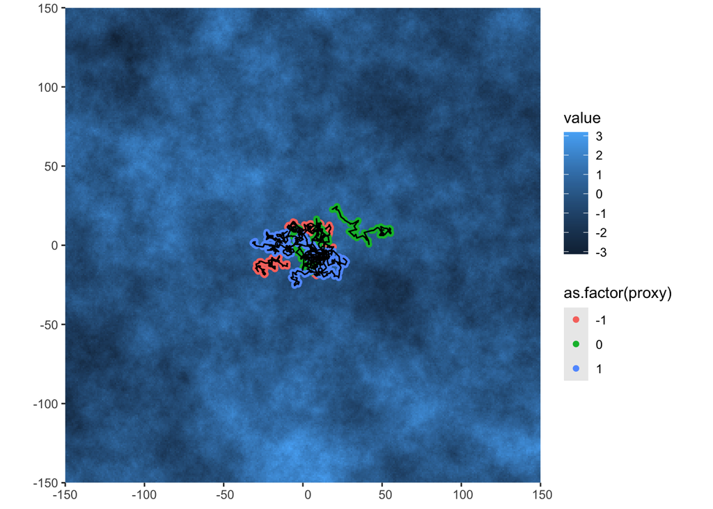

```r
sim.sf <- st_as_sf(sim_t, coords = c("x_", "y_"), remove = FALSE)
sim.sf.path <- sim.sf %>% group_by(ID) %>%
  summarize(ID = unique(ID), do_union=FALSE) %>%
  st_cast("LINESTRING")

ggplot() +
  geom_spatraster(data = cov1) +
  geom_sf(data = sim.sf, aes(col= as.factor(proxy)), lwd = 0.4) +
  geom_sf(data = sim.sf.path) +
  coord_sf(expand = FALSE)
```

# Function to prep data for ssf (simpler version for simulations)

```r
prep.data.ssf.sim <- function(tracks, cov, fit.col.name = "proxy", id.col.name = "ID",
                          x.name = "x_", y.name = "y_", t.name = "t_", n.avail = 10){
# tracks: tibble with locations from simulations
# cov: list of covariate rasters
# fit.col.name: name of column(s) with fitness prox
# id.col.name: name of column in tracks that has the individual id
# x.name: name of column in tracks with x coordinate
# y.name: name of column in tracks with y coordinate
# t.name: name of column in tracks with date time
# n.available: number of available points per used locations

  # Create observed steps
  tracks.id <- tracks %>% nest(.by= c(!! sym(id.col.name), !!! syms(fit.col.name)))
  steps.id <- tracks.id %>%
    mutate(trk = map(data, function(d) {
      d %>% make_track(.x = !! sym(x.name),
                       .y = !! sym(y.name),
                       .t= !! sym(t.name)) %>% steps()}))


  steps.avail <- steps.id
  steps.avail$rp <- NULL

  # We want the parameters used to create the random steps to be from the same distribution (not taken from the estimated for each individual)
  data <- steps.avail %>% dplyr::select(!! sym(id.col.name),
                                        !!! syms(fit.col.name), trk) %>%
    unnest(cols = c(trk))
  gamma_par <-  data$sl_ %>% fit_distr("gamma")
  vonmises_par <- data$ta_ %>% fit_distr("vonmises")

  for(i in 1:nrow(steps.avail)){
    steps.avail[[i,"rp"]][[1]] <- steps.id[[i,"trk"]][[1]] %>%
      random_steps(n_control = n.avail,
                   sl_distr = make_gamma_distr(shape = gamma_par$params$shape,
                                               scale = gamma_par$params$scale,
                                               vcov = gamma_par$vcov),
                   ta_distr = make_vonmises_distr(kappa = vonmises_par$params$kappa,
                                                  vcov = vonmises_par$vcov))
  }


  for(i in seq_along(cov)){
    steps.avail <- steps.avail %>% mutate(rp = map(rp, function(d){
      extract_covariates(d,cov[[i]])}))
  }

  steps.avail <- steps.avail %>% dplyr::select(!! sym(id.col.name),
                                               !!! syms(fit.col.name), rp) %>%
    unnest(cols= c(rp))

  # Important: the `step_id_` will have erroneously similar names across individuals. We change the name here.
  steps.avail$step_id_ <- paste(steps.avail[[id.col.name]], steps.avail$step_id_, sep="_")


  # Get the log sl and cos ta. And numeric case for poisson distribution
  steps.avail$ln_sl <- log(steps.avail$sl_)
  steps.avail$cos_ta <- cos(steps.avail$ta_)
  steps.avail$case_num <- as.numeric(steps.avail$case_)


  return(list(steps.id = steps.id, steps.avail = steps.avail,
              gamma_par=gamma_par, vonmises_par=vonmises_par))
}
```

Let’s test our prep data function on the small simulation. We use 10 available per used locations

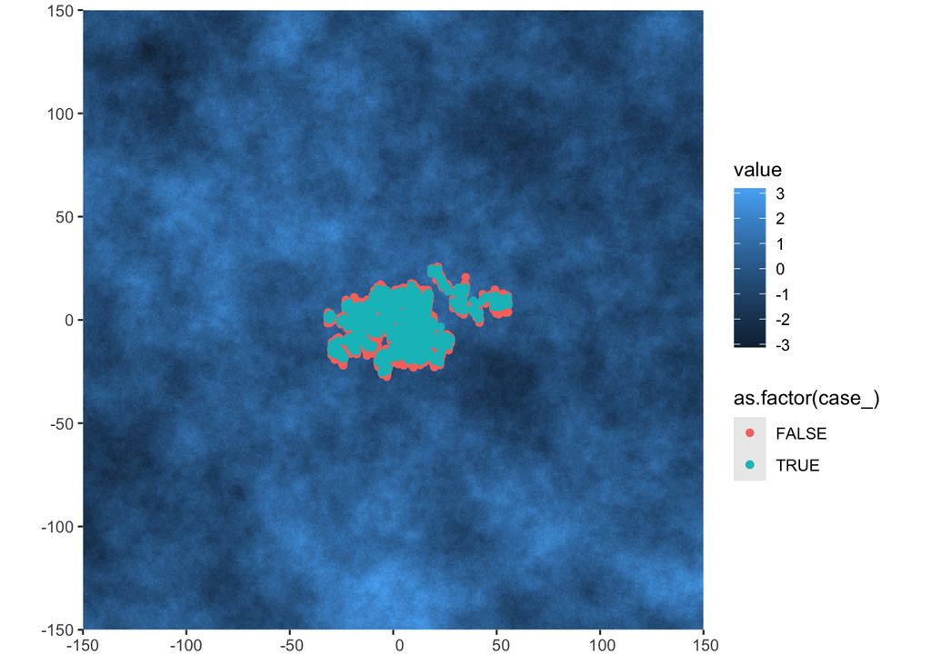

```r
sim.prep <- prep.data.ssf.sim(sim_t, cov=list(cov1 = cov1), n.avail = 10)

sim.prep.sf <- st_as_sf(sim.prep$steps.avail, coords = c("x1_", "y2_"), remove=FALSE)
ggplot() +
  geom_spatraster(data = cov1) +
  geom_sf(data = sim.prep.sf, aes(col= as.factor(case_)), lwd = 0.4) +
  geom_sf(data = sim.prep.sf %>% filter(case_), aes(col= as.factor(case_)), lwd = 0.4) +
  coord_sf(expand = FALSE)
```

There may be warnings that can be ignored.

# Fit model function

Function to fit SSF.

```r
fit.poisson.rs <- function(formula, data,
                           start = list(theta = log(1e3)), map = list(theta=factor(NA))){
  ssf <- glmmTMB(formula, family = poisson,
                 data = data, start = start, map = map)
  return(ssf)
}
```

Test fit function on small simulation

```r
sim.fit <- fit.poisson.rs(formula = case_num ~ -1 +
                                    cov1 + cov1:proxy +
                                    sl_ + ln_sl + cos_ta +
                                    (1 | step_id_) +
                                    (0 + cov1 | ID),
                                  data = sim.prep$steps.avail,
                                  start = list(theta = c(log(1e3),0)),
                                  map=list(theta=factor(c(NA,1))))
summary(sim.fit)
```

```
##  Family: poisson  ( log )
## Formula:
## case_num ~ -1 + cov1 + cov1:proxy + sl_ + ln_sl + cos_ta + (1 |
##     step_id_) + (0 + cov1 | ID)
## Data: data
##
##       AIC       BIC    logLik -2*log(L)  df.resid
##   30552.9   30599.1  -15270.4   30540.9     16329
##
## Random effects:
##
## Conditional model:
##  Groups   Name        Variance  Std.Dev.
##  step_id_ (Intercept) 1.000e+06 1000.0000
##  ID       cov1        3.457e-02    0.1859
## Number of obs: 16335, groups:  step_id_, 1485; ID, 15
##
## Conditional model:
##             Estimate Std. Error z value Pr(>|z|)
## cov1        1.081847   0.162222   6.669 2.58e-11 ***
## sl_        -0.009354   0.042916  -0.218    0.827
## ln_sl       0.019150   0.032959   0.581    0.561
## cos_ta      0.003557   0.045740   0.078    0.938
## cov1:proxy  0.809177   0.195971   4.129 3.64e-05 ***
## ---
## Signif. codes:  0 '***' 0.001 '**' 0.01 '*' 0.05 '.' 0.1 ' ' 1
```

We need a function to convert the estimated movement kernel parameters returned by the model above to the actual values of the estimated shape and scale parameters of the gamma distribution for the step lengths and the concentration parameter of the von Mises distribution for the turning angles. The fitted model above allows for these distributions to be affected by the selection. For more information on this, please see Avgar et al. (2015) and Fieberg et al. (2021), including their Appendix C.

```r
par.adj <- function(gamma.par, von.mises.par, model){
# gamma.par: parameters estimated from the data itself
# model: fitted ssf

  ## Gamma step length distribution
  # Shape parameter after the selection for covariate(s) is accounted for
  ssf_gamma_shape <- gamma.par$params$shape + summary(model)$coef$cond["ln_sl",1]
  # Scale parameter after the selection for covariate(s) is accounted for
  ssf_gamma_scale <- 1/(1/gamma.par$params$scale - summary(model)$coef$cond["sl_",1])
  # Mean of gamma is shape*scale
  ssf_gamma_mean <- ssf_gamma_shape*ssf_gamma_scale


  ## von Mises turning angle distribution
  # Concentration parameter after selection for covariate(s) is accounted for
  ssf_vonMises_kappa <- von.mises.par$params$kappa + summary(model)$coef$cond["cos_ta",1]


  est.par <- list(gamma.shape = ssf_gamma_shape,
                  gamma.scale = ssf_gamma_scale,
                  gamma.mean = ssf_gamma_mean,
                  von.mises.kappa= ssf_vonMises_kappa)


  return(est.par)

}
```

Let’s test the function that uses the estimated parameters based on the observed step length and the fitted coefficients to calculate the estimate selection-free movement parameters.

```r
sim.mov.par <- par.adj(sim.prep$gamma_par, sim.prep$vonmises_par, sim.fit)
```

Compare simulated to estimated parameters

```r
# Movement-free selection parameters
betas_sim.test # Simulated
```

```
## [1] 1 1
```

```r
summary(sim.fit)$coef$cond[c("cov1", "cov1:proxy"),] # Estimated
```

```
##             Estimate Std. Error  z value     Pr(>|z|)
## cov1       1.0818467  0.1622220 6.668925 2.576835e-11
## cov1:proxy 0.8091767  0.1959713 4.129058 3.642527e-05
```

```r
# Selection-free movement-kernel parameters
mov.par_sim.test # Simulated
```

```
## $shape
## [1] 1
##
## $scale
## [1] 1
##
## $kappa
## [1] 1
```

```r
sim.mov.par # Estimated
```

```
## $gamma.shape
## [1] 0.9834774
##
## $gamma.scale
## [1] 1.009879
##
## $gamma.mean
## [1] 0.993193
##
## $von.mises.kappa
## [1] 0.9715974
```

The estimated parameters are close to the simulated values. Though some are further away, but keep in mind this is a small sample size.

Let’s also try it with a model without a relationship with a health proxy.

```r
set.seed(9876)
proxy.n.0 <- rep(5, 3)
cl <- makeCluster(n.cores)

sim.t.0 <- ssf_sim(betas = c(1, 0), mov.par = mov.par_sim.test, val.proxy =  c(0, 0, 0),
                 proxy.n = proxy.n.0, n.steps = 100, m = "proxy_not_in_sel")

stopCluster(cl)
```

```r
sim.prep.0 <- prep.data.ssf.sim(sim.t.0, cov=list(cov1 = cov1), n.avail = 30)
sim.fit.0 <- fit.poisson.rs(formula = case_num ~ -1 +
                                    cov1 +
                                    sl_ + ln_sl + cos_ta +
                                    (1 | step_id_) +
                                    (0 + cov1 | ID),
                                  data = sim.prep.0$steps.avail,
                                  start = list(theta = c(log(1e3),0)),
                                  map=list(theta=factor(c(NA,1))))
sim.mov.par.0 <- par.adj(sim.prep.0$gamma_par, sim.prep.0$vonmises_par, sim.fit.0)
# Movement-free selection parameters
summary(sim.fit.0)$coef$cond["cov1",]
```

```
##     Estimate   Std. Error      z value     Pr(>|z|)
## 8.488709e-01 1.480776e-01 5.732607e+00 9.889842e-09
```

```r
# Selection-free movement-kernel parameters
mov.par_sim.test # Simulated
```

```
## $shape
## [1] 1
##
## $scale
## [1] 1
##
## $kappa
## [1] 1
```

```r
sim.mov.par.0 # Estimated
```

```
## $gamma.shape
## [1] 0.9176359
##
## $gamma.scale
## [1] 1.072303
##
## $gamma.mean
## [1] 0.9839835
##
## $von.mises.kappa
## [1] 1.008407
```

Looks ok.

# Simulations

Basic set up for all simulations, except if otherwise stated.

For all scenarios, we simulate 30 individuals, for movement path with 100 steps, with 100 simulations per scenarios, and 30 available points per step. In all scenarios, the selection-free movement kernels are simulated using a gamma distribution with shape and scale parameters equal 1 for the step lengths and a von Mises distribution with kappa equal 1 for the turning angles (by default the mean is 0).

```r
# Number of individuals
n <- 30
# Number of steps per individual
n.steps <- 100
# Number of simulations per scenario
n.sim <- 100
# Number of available points per used points
n.avail <- 30
# Movement kernel parameter
mov.sc <- list(shape = 1, scale = 1, kappa = 1) # Shape, scale, kappa
```

## Baseline check: verify that we can recover what we should when health/fitness proxy does not alter selection

Here, we verify that the baseline model, which does not include the interaction with the health/fitness proxy, returns unbiased results when there are no difference between individuals. We are verifying that the biases found in the scenarios presented in the main text are linked to the individual differences in health/fitness not a problem with the baseline model.

We simulate location data based on SSF without any health or fitness proxy, and make sure we recover parameter estimates.

```r
betas.sc1 <- c(0.5, 0)
val.proxy.sc1 <- c(-1, 0, 1)

sim.res.sc1 <- as.data.frame(matrix(nrow = n.sim, ncol = 16))
colnames(sim.res.sc1) <- c("sim", "beta_cov_sim", "beta_cov_est", "beta_cov_SE",
                           "beta_cov_95LCI", "beta_cov_95UCI", "beta_cov_in_95CI",
                           "gamma_shape_sim", "gamma_scale_sim", "vonMises_kappa_sim",
                           "gamma_shape_est", "gamma_scale_est", "vonMises_kappa_est",
                           "converg.mess", "AICc_baseline", "AICc_new")
```

**This will take mins to hours to run on most computers.** We provided a .csv file with the results in the repository that can be loaded below.

```r
set.seed(1234567)
cl <- makeCluster(n.cores)
t0 <- Sys.time()
for(s in 1:n.sim){
  sim.res.sc1[s, "sim"] <- s
  sim.res.sc1[s, "beta_cov_sim"] <- betas.sc1[1]
  sim.res.sc1[s, "gamma_shape_sim"] <- mov.sc$shape
  sim.res.sc1[s, "gamma_scale_sim"] <- mov.sc$scale
  sim.res.sc1[s, "vonMises_kappa_sim"] <- mov.sc$kappa
  cov.s <- simulate_data(study.area, n = 1, scale = 0.9, sd = 0.1)
  sim.s <- ssf_sim(betas = betas.sc1, mov.par = mov.sc, val.proxy = val.proxy.sc1,
                 proxy.n = rep(n/3, 3), # balanced ratio
                 n.steps = n.steps, m = "proxy_not_in_sel")

  all.s <- prep.data.ssf.sim(sim.s, cov = list(cov1 = cov1), n.avail = n.avail)
  fit.s <- fit.poisson.rs(formula = case_num ~ -1 +
                                    cov1 +
                                    sl_ + ln_sl + cos_ta +
                                    (1 | step_id_) +
                                    (0 + cov1 | ID),
                                  data = all.s$steps.avail,
                                  start = list(theta = c(log(1e3),0)),
                                  map = list(theta = factor(c(NA,1))))
  sim.res.sc1[s, c("beta_cov_est", "beta_cov_SE")] <-
    summary(fit.s)$coef$cond[c("cov1"), c("Estimate", "Std. Error")]
  sim.res.sc1[s, c("beta_cov_95LCI", "beta_cov_95UCI")] <- confint(fit.s, "cov1")[,1:2]
  par.s <- par.adj(all.s$gamma_par, all.s$vonmises_par, fit.s)
  sim.res.sc1[s, "gamma_shape_est"] <- par.s$gamma.shape
  sim.res.sc1[s, "gamma_scale_est"] <- par.s$gamma.scale
  sim.res.sc1[s, "vonMises_kappa_est"] <- par.s$von.mises.kappa
  sim.res.sc1[s, "converg.mess"] <- fit.s$fit$convergence # 0 means that the model converged
  sim.res.sc1[s, "AICc_baseline"] <- AICc(fit.s)

  # New model
  fit.new.s <- fit.poisson.rs(formula = case_num ~ -1 +
                                    cov1 + cov1:proxy +
                                    sl_ + ln_sl + cos_ta +
                                    (1 | step_id_) +
                                    (0 + cov1 | ID),
                                  data = all.s$steps.avail,
                                  start = list(theta = c(log(1e3),0)),
                                  map=list(theta=factor(c(NA,1))))
    sim.res.sc1[s, "AICc_new"] <- AICc(fit.new.s)
}
Sys.time() - t0
```

```
## Time difference of 41.66017 mins
```

```r
# Check if in CI
sim.res.sc1$beta_cov_in_95CI <- sim.res.sc1$beta_cov_95LCI <= sim.res.sc1$beta_cov_sim &
  sim.res.sc1$beta_cov_sim <= sim.res.sc1$beta_cov_95UCI

# Look at AICc difference,  new model (wrong model, more complex) - baseline model (good model)
sim.res.sc1$deltaAICc <- sim.res.sc1$AICc_new - sim.res.sc1$AICc_baseline

# Save file
write.csv(sim.res.sc1,
          file = paste("sim.ssf.sc1_", format(Sys.time(), "%Y%m%d"), ".csv",
                               sep=""),
          row.names = FALSE)
stopCluster(cl)
```

To load the saved results, uncomment the first line.

```r
#sim.res.sc1 <- read.csv("sim.ssf.sc1_20251112.csv")
head(sim.res.sc1)
```

```
##   sim beta_cov_sim beta_cov_est beta_cov_SE beta_cov_95LCI beta_cov_95UCI
## 1   1          0.5    0.7059875   0.1045281      0.5011161      0.9108589
## 2   2          0.5    0.4424530   0.1037456      0.2391153      0.6457906
## 3   3          0.5    0.4294877   0.1034749      0.2266806      0.6322948
## 4   4          0.5    0.5478612   0.1049151      0.3422313      0.7534910
## 5   5          0.5    0.6345893   0.1038520      0.4310431      0.8381355
## 6   6          0.5    0.4556422   0.1037727      0.2522514      0.6590329
##   beta_cov_in_95CI gamma_shape_sim gamma_scale_sim vonMises_kappa_sim
## 1            FALSE               1               1                  1
## 2             TRUE               1               1                  1
## 3             TRUE               1               1                  1
## 4             TRUE               1               1                  1
## 5             TRUE               1               1                  1
## 6             TRUE               1               1                  1
##   gamma_shape_est gamma_scale_est vonMises_kappa_est converg.mess AICc_baseline
## 1       1.0009135       0.9742000          0.9845002            0      67333.90
## 2       0.9805874       1.0380922          0.9975758            0      67361.54
## 3       1.0180914       0.9847639          1.0071600            0      67361.77
## 4       0.9772115       1.0014364          0.9967008            0      67352.36
## 5       0.9709452       1.0273702          0.9800529            0      67340.67
## 6       1.0255873       0.9724170          0.9929904            0      67358.86
##   AICc_new deltaAICc
## 1 67335.69 1.7893218
## 2 67363.11 1.5729036
## 3 67362.74 0.9692921
## 4 67354.01 1.6451101
## 5 67341.63 0.9583559
## 6 67359.63 0.7728728
```

Let’s look whether AICc would select the good model. Here the baseline model should have the lowest AICc, and thus the difference should be positive.

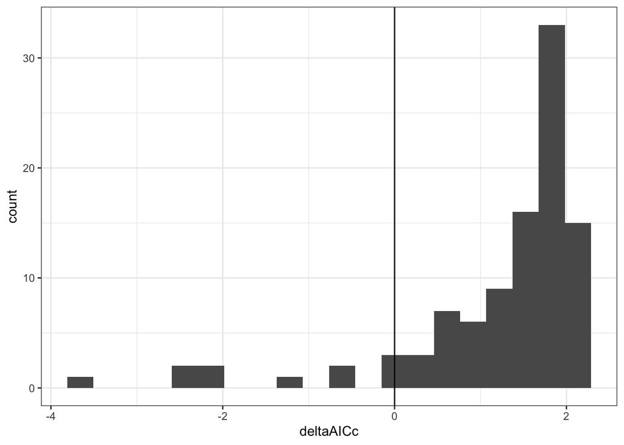

```r
ggplot(data = sim.res.sc1) +
  geom_histogram(aes(x = deltaAICc), bins = 20) +
  theme_bw() +
  geom_vline(xintercept = 0)
```

How many are negative?

```r
sim.res.sc1 %>% filter(deltaAICc < 0) %>% nrow()
```

```
## [1] 9
```

Thus, AICc would choose the wrong model 9% of the time.

If we only select the new model if the difference is greater than 2 (i.e. 2 times the number of parameter difference).

```r
sim.res.sc1 %>% filter(deltaAICc < -2) %>% nrow()
```

```
## [1] 4
```

So we choose the wrong model only 4% of the time (i.e., type I error rate is 4%). This may change with sample size.

Let’s check the coverage for the habitat selection coefficient. It should be $\approx$ 95%.

```r
sum(sim.res.sc1$beta_cov_in_95CI)/n.sim
```

```
## [1] 0.96
```

It is close to the 95% coverage we expected.

Let’s look at the selection and movement kernel parameters

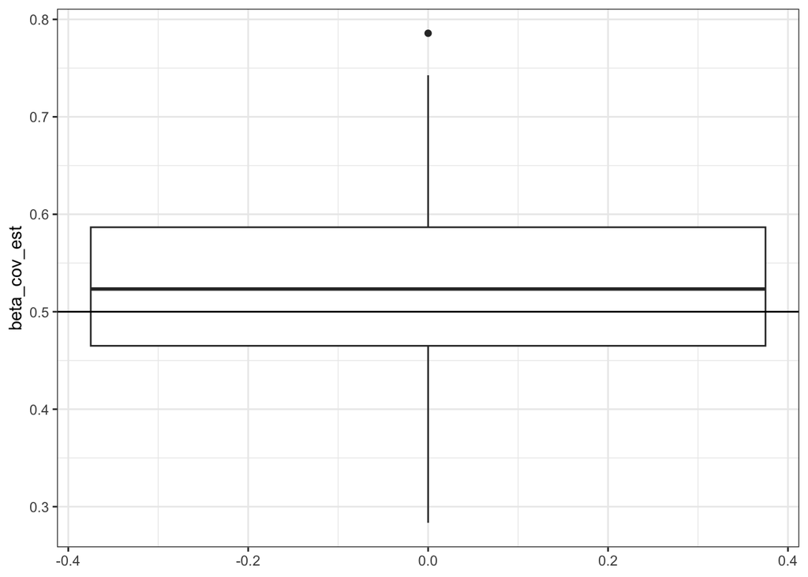

```r
# Selection
ggplot(data = sim.res.sc1) +
  geom_boxplot(aes(y = beta_cov_est)) +
  geom_hline(aes(yintercept = unique(beta_cov_sim))) +
  theme_bw()
```

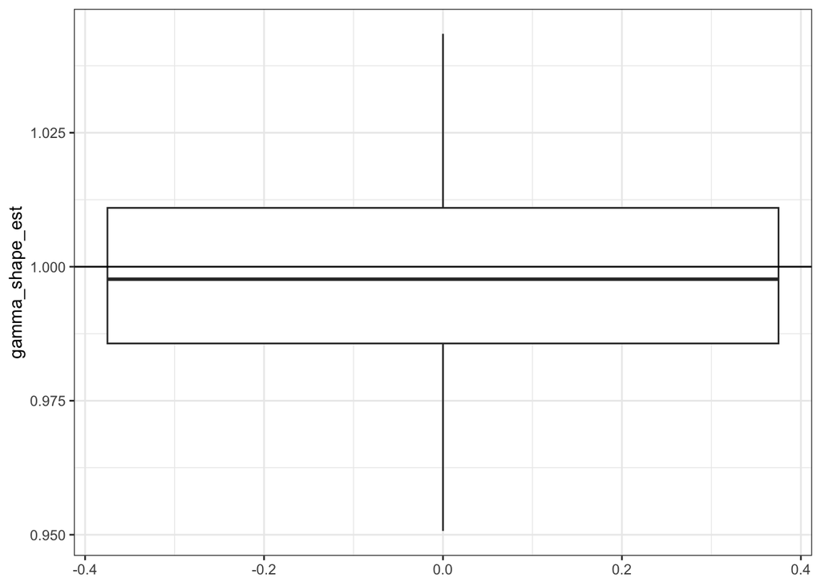

```r
# Gamma shape
ggplot(data = sim.res.sc1) +
  geom_boxplot(aes(y = gamma_shape_est)) +
  geom_hline(aes(yintercept = unique(gamma_shape_sim))) +
  theme_bw()
```

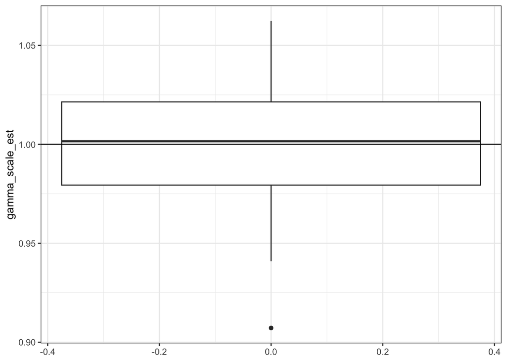

```r
# Gamma scale
ggplot(data = sim.res.sc1) +
  geom_boxplot(aes(y = gamma_scale_est)) +
  geom_hline(aes(yintercept = unique(gamma_scale_sim))) +
  theme_bw()
```

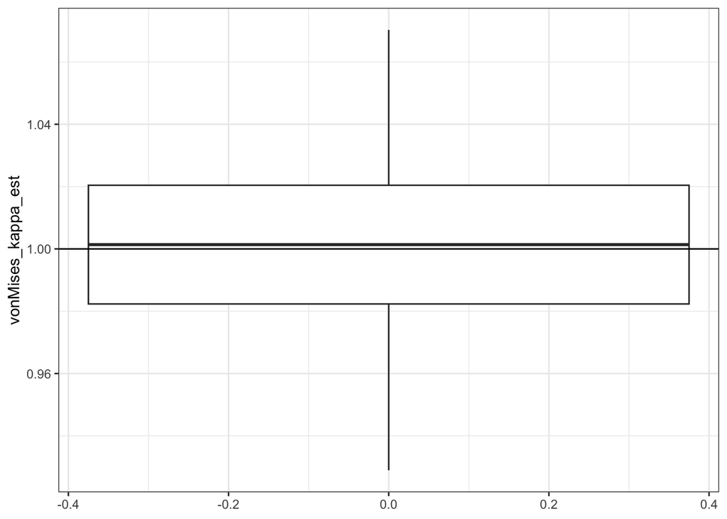

```r
# von Mises kappa
ggplot(data = sim.res.sc1) +
  geom_boxplot(aes(y = vonMises_kappa_est)) +
  geom_hline(aes(yintercept = unique(vonMises_kappa_sim))) +
  theme_bw()
```

The estimated values are close to the simulated values.

## Main scenarios: see what happens when individual differ, but the proxy is not included vs included

Here, we will create simulations where an individual’s health/fitness proxy value affects the selection. We will use these simulations to demonstrate that ignoring health/fitness proxies can bias our results. These are based on the resource selection function (RSF) scenarios, but we are now looking at step selection function (SSF).

We will look at two SSF scenarios:

**Scenario C** (sometimes referred as `sc2.c` in the code): There is a general trend towards selecting higher values of the environmental covariate, but those with higher health/fitness proxy value do so more strongly, and those with lower health/fitness proxy value (i.e., -1, see below) avoid areas with higher values of this environmental covariate. This scenario could represent lower health/fitness individuals being out-competed by individuals in better conditions, and have to go to lower quality habitat. In this case $\beta_1 = 0.5$ and $\beta_2 = 1$.

**Scenario D** (sometimes referred as `sc2.d` in the code): Individuals do not generally select for higher or lower values of the covariate, but individuals with higher fitness specifically avoid higher values while those of lower fitness do select these higher values. In this case $\beta_1 = 0$ and $\beta_2 = -1$.

For all scenarios, the proxy values can be either -1 (less healthy/fit than average), 0 (average individual), and 1 (more healthy/fit than average). We have sub-scenarios where we modify the ratio of individuals with each proxy values: i) 3:2:1 (more individuals with proxy value of -1), ii) 1:1:1 (balanced), and iii) 1:2:3 (more individuals with proxy value of 1).

This code chunk defines the scenario settings.

```r
# Two scenarios
betas.sc2 <- matrix(c(0.5, 1, # Scenario C
                      0, -1), # Scenario D
                    nrow = 2, byrow=TRUE)

val.proxy.sc2 <- c(-1, 0, 1)

# Sub-scenarios
# This work with n = 30
proxy.sc2 <- rbind(c(n/6*3, n/6*2, n/6), # i
                   c(n/6*2, n/6*2, n/6*2), # ii
                   c(n/6*1, n/6*2, n/6*3)) # iii
colnames(proxy.sc2) <- c("n_m1", "n_0", "n_p1")

# Table for results
sim.res.sc2 <- as.data.frame(matrix(nrow = n.sim*nrow(proxy.sc2)*2, ncol = 32))
colnames(sim.res.sc2) <- c("sim", "n_m1", "n_0", "n_p1", "cov.sim.index",
                           "beta_cov_sim", "beta_cov_proxy_sim",
                           "gamma_shape_sim", "gamma_scale_sim", "vonMises_kappa_sim",
                           "beta_cov_est", "beta_cov_SE",
                           "beta_cov_95LCI", "beta_cov_95UCI", "beta_cov_in_95CI",
                           "beta_cov_est_new", "beta_cov_SE_new",
                           "beta_cov_95LCI_new", "beta_cov_95UCI_new",
                           "beta_cov_in_95CI_new",
                           "beta_cov_proxy_est_new", "beta_cov_proxy_SE_new",
                           "beta_cov_proxy_95LCI_new", "beta_cov_proxy_95UCI_new",
                           "beta_cov_proxy_in_95CI_new",
                           "gamma_shape_est", "gamma_scale_est", "vonMises_kappa_est",
                           "converg_mess_baseline", "converg_mess_new",
                           "AICc_baseline", "AICc_new")

# Simulation ID
sim.res.sc2[,"sim"] <- 1:(n.sim*nrow(betas.sc2)*nrow(proxy.sc2))

# Index of covariate used
sim.res.sc2[,"cov.sim.index"] <- rep(1:n.sim, nrow(betas.sc2)*nrow(proxy.sc2))

# Number of individuals (sub-scenarios)
sim.res.sc2[, "n_m1"] <- rep(proxy.sc2[,"n_m1"], each = n.sim*nrow(betas.sc2))
sim.res.sc2[, "n_0"] <- rep(proxy.sc2[,"n_0"], each = n.sim*nrow(betas.sc2))
sim.res.sc2[, "n_p1"] <- rep(proxy.sc2[,"n_p1"], each = n.sim*nrow(betas.sc2))

# Betas (scenarios)
sim.res.sc2[, "beta_cov_sim"] <- rep(betas.sc2[,1], each = n.sim)
sim.res.sc2[, "beta_cov_proxy_sim"] <- rep(betas.sc2[,2], each = n.sim)

# Movement kernel (scenarios)
sim.res.sc2[, "gamma_shape_sim"] <- mov.sc$shape
sim.res.sc2[, "gamma_scale_sim"] <- mov.sc$scale
sim.res.sc2[, "vonMises_kappa_sim"] <- mov.sc$kappa

# As factor
sim.res.sc2$beta_sim_factor <- paste(sim.res.sc2$beta_cov_sim, sim.res.sc2$beta_cov_proxy_sim)
sim.res.sc2$proxy_factor <- factor(paste("-1: ", sim.res.sc2$n_m1,
                                        ", 0: ", sim.res.sc2$n_0,
                                        ", +1: ", sim.res.sc2$n_p1, sep = ""),
                                      levels = c("-1: 15, 0: 10, +1: 5",
                                                 "-1: 10, 0: 10, +1: 10",
                                                 "-1: 5, 0: 10, +1: 15"))
```

**This will take mins to hours to run on most computers.** We provided a .csv file with the results in the repository that can be loaded below.

```r
set.seed(1234567)
cl <- makeCluster(n.cores)
t0 <- Sys.time()
for(s in 1:(n.sim*3*2)){
  cov.s <- simulate_data(study.area, n = 1, scale = 0.9, sd = 0.1)

  beta.s <- as.numeric(sim.res.sc2[s,c("beta_cov_sim", "beta_cov_proxy_sim")])
  mov.s <- list(shape = sim.res.sc2[s,"gamma_shape_sim"],
                scale = sim.res.sc2[s,"gamma_scale_sim"],
                kappa = sim.res.sc2[s,"vonMises_kappa_sim"])
  proxy.n.s <- as.numeric(sim.res.sc2[s, c("n_m1", "n_0", "n_p1")])

  sim.s <- ssf_sim(betas = beta.s,
                   mov.par = mov.s,
                   val.proxy = val.proxy.sc2,
                   proxy.n = proxy.n.s, n.steps = n.steps, m = "proxy_in_sel")

  all.s <- prep.data.ssf.sim(tracks = sim.s, cov = list(cov1 = cov1), n.avail = n.avail)


  # Baseline model, exclude proxy
  fit.s <- fit.poisson.rs(formula = case_num ~ -1 +
                                    cov1 +
                                    sl_ + ln_sl + cos_ta +
                                    (1 | step_id_) +
                                    (0 + cov1 | ID),
                                  data = all.s$steps.avail,
                                  start = list(theta = c(log(1e3),0)),
                                  map = list(theta = factor(c(NA,1))))

  sim.res.sc2[s, c("beta_cov_est", "beta_cov_SE")] <-
    summary(fit.s)$coef$cond[c("cov1"), c("Estimate", "Std. Error")]
  sim.res.sc2[s, c("beta_cov_95LCI", "beta_cov_95UCI")] <-
    confint(fit.s, "cov1")[,1:2]
  par.s <- par.adj(all.s$gamma_par, all.s$vonmises_par, fit.s)
  sim.res.sc2[s, "gamma_shape_est"] <- par.s$gamma.shape
  sim.res.sc2[s, "gamma_scale_est"] <- par.s$gamma.scale
  sim.res.sc2[s, "vonMises_kappa_est"] <- par.s$von.mises.kappa
  sim.res.sc2[s, "converg_mess_baseline"] <- fit.s$fit$convergence # 0 = model converged
  sim.res.sc2[s, "AICc_baseline"] <- AICc(fit.s)

  # New model with proxy
  fit.new.s <- fit.poisson.rs(formula = case_num ~ -1 +
                                    cov1 + cov1:proxy +
                                    sl_ + ln_sl + cos_ta +
                                    (1 | step_id_) +
                                    (0 + cov1 | ID),
                                  data = all.s$steps.avail,
                                  start = list(theta = c(log(1e3),0)),
                                  map=list(theta=factor(c(NA,1))))

  sim.res.sc2[s, c("beta_cov_est_new", "beta_cov_SE_new")] <-
    summary(fit.new.s)$coef$cond[c("cov1"), c("Estimate", "Std. Error")]
  sim.res.sc2[s, c("beta_cov_proxy_est_new", "beta_cov_proxy_SE_new")] <-
    summary(fit.new.s)$coef$cond[c("cov1:proxy"), c("Estimate", "Std. Error")]

  sim.res.sc2[s, c("beta_cov_95LCI_new", "beta_cov_95UCI_new")] <-
    confint(fit.new.s, "cov1")[,1:2]
  sim.res.sc2[s, c("beta_cov_proxy_95LCI_new", "beta_cov_proxy_95UCI_new")] <-
    confint(fit.new.s, "cov1:proxy")[,1:2]
  par.new.s <- par.adj(all.s$gamma_par, all.s$vonmises_par, fit.new.s)
  sim.res.sc2[s, "gamma_shape_est_new"] <- par.new.s$gamma.shape
  sim.res.sc2[s, "gamma_scale_est_new"] <- par.new.s$gamma.scale
  sim.res.sc2[s, "vonMises_kappa_est_new"] <- par.new.s$von.mises.kappa
  sim.res.sc2[s, "converg_mess_new"] <- fit.new.s$fit$convergence # 0 = model converged
  sim.res.sc2[s, "AICc_new"] <- AICc(fit.new.s)


}
Sys.time() - t0
```

```
## Time difference of 3.91874 hours
```

```r
### Check if in CI

# Baseline
sim.res.sc2$beta_cov_in_95CI <- sim.res.sc2$beta_cov_95LCI <= sim.res.sc2$beta_cov_sim &
  sim.res.sc2$beta_cov_sim <= sim.res.sc2$beta_cov_95UCI

# New model with proxy
sim.res.sc2$beta_cov_in_95CI_new <- sim.res.sc2$beta_cov_95LCI_new <=
  sim.res.sc2$beta_cov_sim &
  sim.res.sc2$beta_cov_sim <= sim.res.sc2$beta_cov_95UCI_new

sim.res.sc2$beta_cov_proxy_in_95CI_new <- sim.res.sc2$beta_cov_proxy_95LCI_new <=
  sim.res.sc2$beta_cov_proxy_sim &
  sim.res.sc2$beta_cov_proxy_sim <= sim.res.sc2$beta_cov_proxy_95UCI_new

# Look at AICc difference,  here  baseline model (wrong model, too simple) - new model (good model)
sim.res.sc2$deltaAICc <- sim.res.sc2$AICc_baseline - sim.res.sc2$AICc_new



# Save file
write.csv(sim.res.sc2,
          file = paste("sim.ssf.sc2_", format(Sys.time(), "%Y%m%d"), ".csv",
                               sep=""),
          row.names = FALSE)
stopCluster(cl)
```

To load the saved results, uncomment the lines in this code chunk.

```r
# sim.res.sc2 <- read.csv("sim.ssf.sc2_20251112.csv")
# sim.res.sc2$proxy_factor <- factor(sim.res.sc2$proxy_factor,
#                                       levels = c("-1: 15, 0: 10, +1: 5",
#                                                  "-1: 10, 0: 10, +1: 10",
#                                                  "-1: 5, 0: 10, +1: 15"))
```

Above was the previous more detailed names. New labels below.

```r
sim.res.sc2$proxy_sf <-  factor(paste(sim.res.sc2$n_m1,
                                      sim.res.sc2$n_0,
                                      sim.res.sc2$n_p1, sep = ":"),
                                      levels = c("15:10:5",
                                                 "10:10:10",
                                                 "5:10:15"))
```

There are many warnings (not shown in compiled version). Check convergence messages and if there are any problem with estimating the SE

```r
# How many have convergence problems - baseline
sum(sim.res.sc2[,"converg_mess_baseline"] != 0)
```

```
## [1] 0
```

```r
sum(is.na(sim.res.sc2[,"beta_cov_SE"]))
```

```
## [1] 0
```

```r
which(is.na(sim.res.sc2[,"beta_cov_SE"]))
```

```
## integer(0)
```

```r
# How many have convergence problems - new
sum(sim.res.sc2[,"converg_mess_new"] != 0)
```

```
## [1] 0
```

```r
sum(is.na(sim.res.sc2[,"beta_cov_SE_new"]))
```

```
## [1] 0
```

```r
which(is.na(sim.res.sc2[,"beta_cov_SE_new"]))
```

```
## integer(0)
```

```r
sum(is.na(sim.res.sc2[,"beta_cov_proxy_SE_new"]))
```

```
## [1] 0
```

```r
which(is.na(sim.res.sc2[,"beta_cov_proxy_SE_new"]))
```

```
## integer(0)
```

There are no convergence message, and none of the simulations returned NAs for the SEs.

```r
head(sim.res.sc2)
```

```
##   sim n_m1 n_0 n_p1 cov.sim.index beta_cov_sim beta_cov_proxy_sim
## 1   1   15  10    5             1          0.5                  1
## 2   2   15  10    5             2          0.5                  1
## 3   3   15  10    5             3          0.5                  1
## 4   4   15  10    5             4          0.5                  1
## 5   5   15  10    5             5          0.5                  1
## 6   6   15  10    5             6          0.5                  1
##   gamma_shape_sim gamma_scale_sim vonMises_kappa_sim beta_cov_est beta_cov_SE
## 1               1               1                  1    0.1064816   0.1943120
## 2               1               1                  1    0.1724693   0.1787234
## 3               1               1                  1    0.2129730   0.1370072
## 4               1               1                  1    0.2237240   0.1558617
## 5               1               1                  1    0.1165243   0.1879674
## 6               1               1                  1    0.1946921   0.2054220
##   beta_cov_95LCI beta_cov_95UCI beta_cov_in_95CI beta_cov_est_new
```

[output cut: 55 more lines]

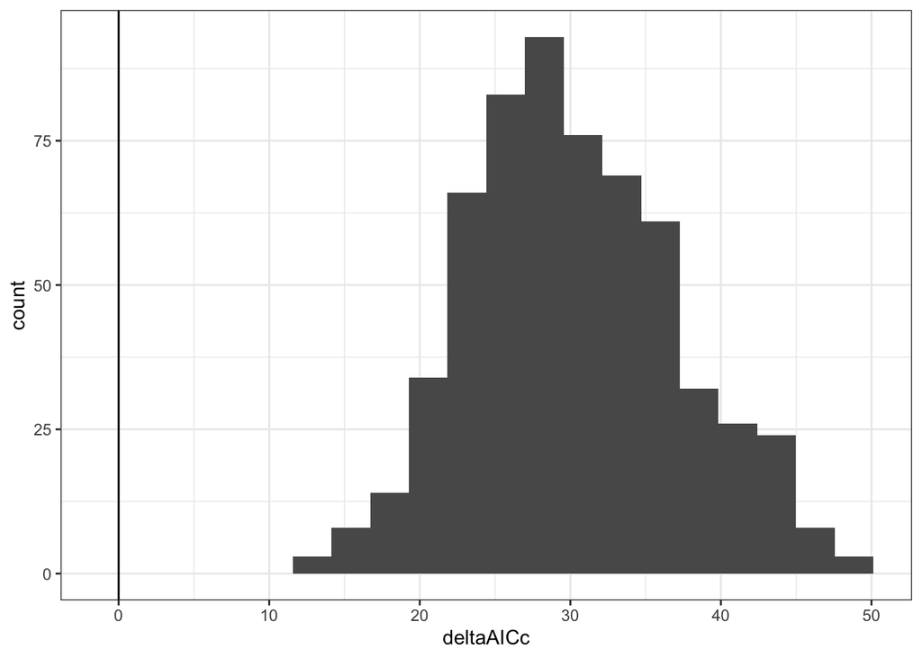

```r
ggplot(data = sim.res.sc2) +
  geom_histogram(aes(x=deltaAICc), bins=20) +
  theme_bw() +
  geom_vline(xintercept = 0)
```

Let’s verify that there are no negative values.

```r
sim.res.sc2 %>% filter(deltaAICc < 0) %>% nrow()
```

```
## [1] 0
```

Thus, AICc would choose the wrong model 0% of the time.

```r
sim.res.sc2 %>% filter(deltaAICc < -2) %>% nrow()
```

```
## [1] 0
```

Thus, if we assume that the baseline model is the null model type II error rate is 0% (i.e., power of 100%). The power will change with sample size, etc.

Let’s calculate coverage.

In case some random seeds returned NA for SE, we remove those simulations before calculating coverage.

```r
# Model without proxy
sum(sim.res.sc2$beta_cov_in_95CI, na.rm = TRUE)/(nrow(sim.res.sc2) -
                                                   sum(is.na(sim.res.sc2[,"beta_cov_SE"])))
```

```
## [1] 0.6683333
```

```r
# Model with proxy - general selection
sum(sim.res.sc2$beta_cov_in_95CI_new, na.rm = TRUE)/(nrow(sim.res.sc2) -
                                                      sum(is.na(sim.res.sc2[,"beta_cov_SE_new"])))
```

```
## [1] 0.9566667
```

```r
# Model with proxy - relationship with proxy
sum(sim.res.sc2$beta_cov_proxy_in_95CI_new, na.rm = TRUE)/(nrow(sim.res.sc2) - sum(is.na(sim.res.sc2[,"beta_cov_proxy_SE_new"])))
```

```
## [1] 0.9633333
```

As expected when we ignore the relationship with the proxy, the true underlying relationship is often not captured (poor coverage), but if we fit the good model we get a coverage of about 95%.

In scenario C, which has a baseline selection for the covariate of 0.5 and a 1:1 relationship with the health/fitness proxy, the environmental covariate is important for animal, especially for those in superior health. Let’s see how often the baseline model, which does not include the relationship with the health/fitness proxy, would conclude that this environmental covariate is not important. To do so, we will calculate how many confidence intervals (CIs) from the estimated coefficient from the baseline model overlap with 0.

```r
res.sc2.c <- subset(sim.res.sc2, beta_cov_sim == 0.5 & beta_cov_proxy_sim == 1)
res.sc2.c$zero_in_CI <- res.sc2.c$beta_cov_95LCI <= 0 & res.sc2.c$beta_cov_95UCI >= 0

res.sc2.c %>% group_by(proxy_factor)  %>% summarise(n = sum(zero_in_CI))
```

```
## # A tibble: 3 × 2
##   proxy_factor              n
##   <fct>                 <int>
## 1 -1: 15, 0: 10, +1: 5     93
## 2 -1: 10, 0: 10, +1: 10     6
## 3 -1: 5, 0: 10, +1: 15      0
```

While the CIs of simulations where there are more individuals in good condition or a balanced number of individuals across condition rarely overlap with 0, the CIs of 93% of the simulations where there are more individuals in poor condition overlap with 0.

Scenario D has a baseline selection of the covariate of 0 and a negative relationship with the health/fitness proxy, meaning that in general the animal does not select for the environmental covariate and that healthy animals avoid it. Here only individuals in poor condition select it. To see whether ignoring the health/fitness proxy could mislead us to think that this environmental covariate is important for the health of animal, we look at how many CI are fully above zero (which would be interpreted as selecting the covariate).

```r
res.sc2.d <- subset(sim.res.sc2, beta_cov_sim == 0 & beta_cov_proxy_sim == -1)
res.sc2.d$positive_CI <- res.sc2.d$beta_cov_95LCI > 0 & res.sc2.d$beta_cov_95UCI > 0

res.sc2.d %>% group_by(proxy_factor)  %>% summarise(n = sum(positive_CI, na.rm=TRUE))
```

```
## # A tibble: 3 × 2
##   proxy_factor              n
##   <fct>                 <int>
## 1 -1: 15, 0: 10, +1: 5     55
## 2 -1: 10, 0: 10, +1: 10     0
## 3 -1: 5, 0: 10, +1: 15      0
```

While it’s not an issue when there are more individuals that are healthy or when there is a balanced number of individuals in each health category, 55% of the simulations with more individuals in poor health would show selection of this covariate (which is avoided by the healthy animals!).

Let’s look at coefficient estimates.

```r
col.base.method <- "black"
col.new.method <- "hotpink"
# sim.res <- sim.res.sc2
# beta_scenario <- "0.5 1"
plot.sim.boxplot <- function(sim.res, beta_scenario, par.name = c("beta_cov_sim", "beta_cov_est", "beta_cov_est_new"),
                             y.title = expression(hat(beta)[1]), x.title = "Ratio of individuals (Inferior:Average:Superior)"){
  subset.sc <- subset(sim.res, beta_sim_factor == beta_scenario)
  beta.sc <- subset.sc %>% pull(!! sym(par.name[1])) %>% unique()
  p <- ggplot() +
    geom_boxplot(data = subset.sc, aes(x= proxy_sf, y = !! sym(par.name[2])),
                 width = 0.25, position= position_nudge(x=-.15),
                 col = col.base.method, fill = alpha(col.base.method, 0.5)) +
    geom_boxplot(data = subset.sc, aes(x= proxy_sf, y= !! sym(par.name[3])),
                 width = 0.25, position= position_nudge(x=+.15),
                 col = col.new.method, fill = alpha(col.new.method, 0.5)) +
    geom_hline(aes(yintercept = beta.sc)) +
    xlab(x.title) + ylab(y.title) +
    theme(panel.border = element_rect(fill = NA, linewidth = 0.5)) +
    guides(Without.proxy = guide_custom(grid::circleGrob(r = unit(0.1, "cm"),
                                                  gp = grid::gpar(fill = col.base.method,
                                                                  col = NA)),
                                 title = "Ignoring fitness proxy", order = 1,
                                 theme = theme(legend.title =
                                                 element_text(size = axis.label.size),
                                               legend.position = "top")),
           With.proxy = guide_custom(grid::circleGrob(r = unit(0.1, "cm"),
                                                  gp = grid::gpar(fill = col.new.method,
                                                                  col = NA)),
                                 title = "Including fitness proxy", order = 2,
                                 theme = theme(legend.title =
                                                 element_text(size = axis.label.size),
                                               legend.position = "top"))) +
        theme_classic() +
    theme(legend.position = "top",
          axis.title = element_text(size = axis.title.size),
          axis.text = element_text(size = axis.label.size),
          panel.border = element_rect(colour = "black", fill = NA, linewidth = 0.5),
          axis.line = element_line(colour = 'black', linewidth = 0.1),
          axis.ticks = element_line(colour = 'black', linewidth = 0.1),
          plot.margin = unit(c(1.05, 1.15, 0, 1), 'lines'))
  return(p)
}
```

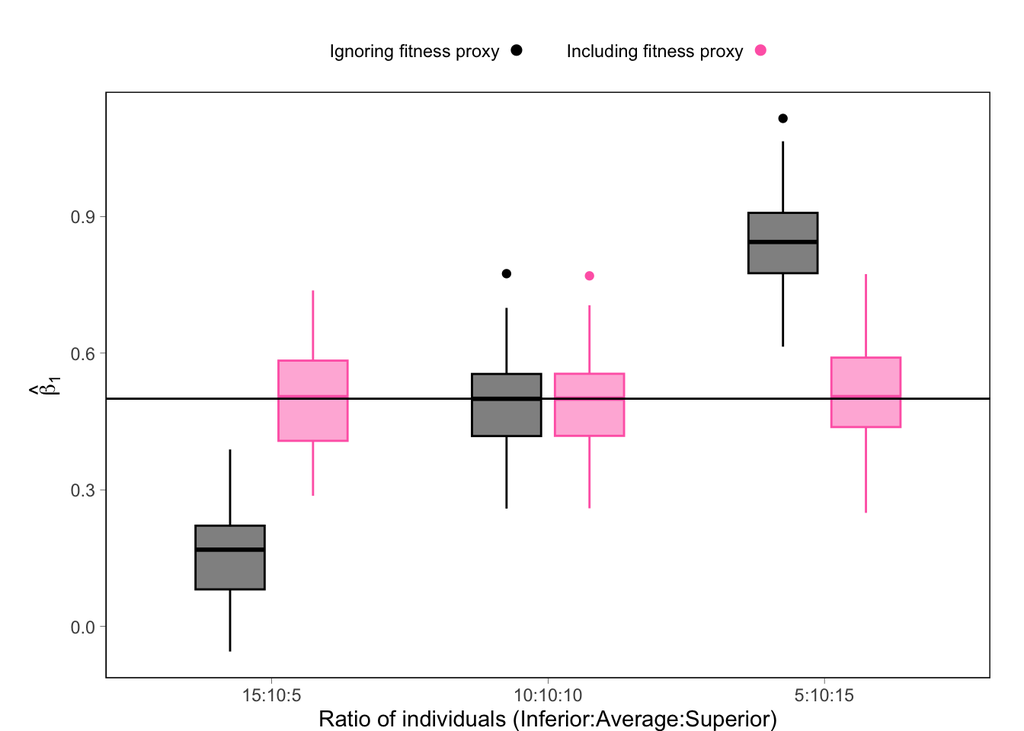

```r
# Scenarios
plot.2.c <- plot.sim.boxplot(sim.res.sc2, "0.5 1")
plot.2.c
```

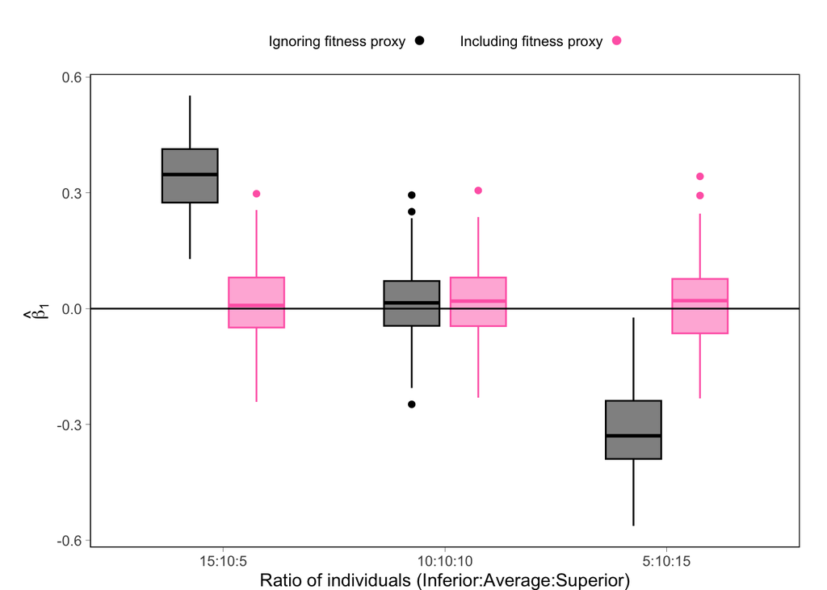

```r
plot.2.d <- plot.sim.boxplot(sim.res.sc2, "0 -1")
plot.2.d
```

```r
legend.plot.rel <- as_ggplot(get_legend(plot.2.c))
```

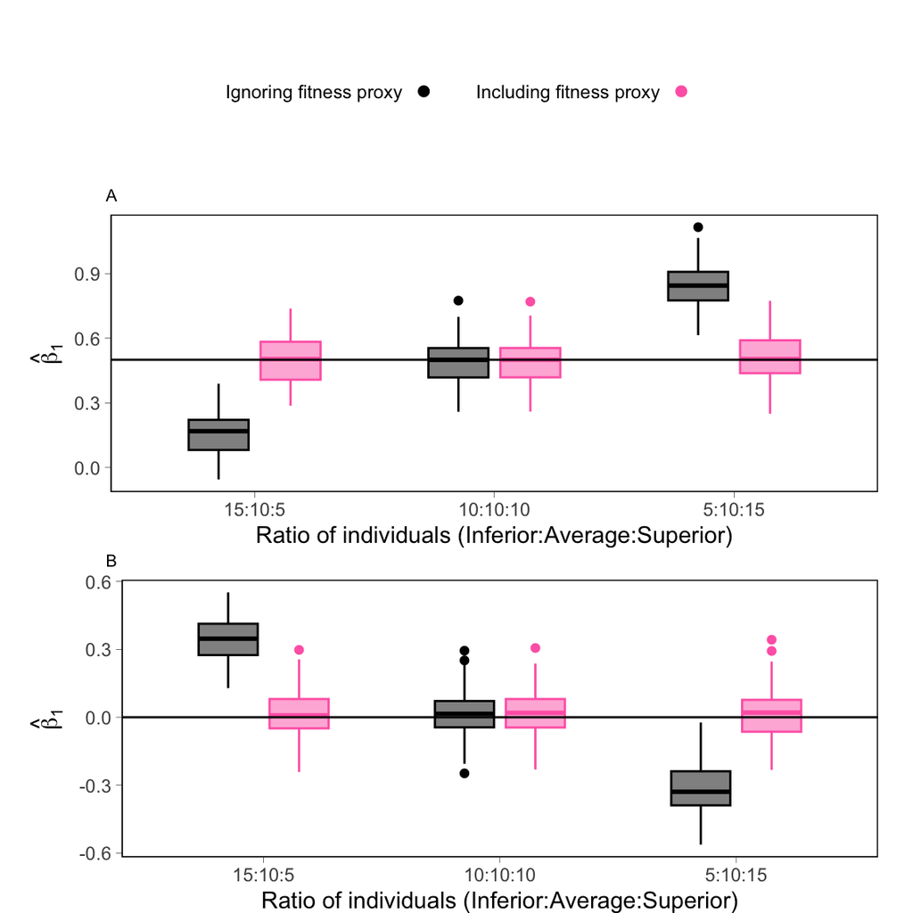

```r
ggarrange(legend.plot.rel,
  ggarrange(plot.2.c, plot.2.d,  legend = "none",
          labels = c("A", "B"), label.x = rep(0.11,4), label.y = rep(1, 4),
              font.label = list(size = 8, face="plain"),
          nrow = 2, ncol = 1), nrow=2, ncol=1, heights = c(0.2,0.8))
```

Here we also look at the movement kernel parameters.

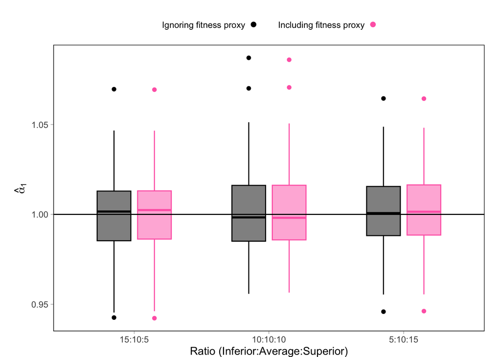

```r
# Scenarios
plot.2.c.gamma.shape <- plot.sim.boxplot(sim.res.sc2, "0.5 1",
                             par.name = c("gamma_shape_sim",
                                          "gamma_shape_est", "gamma_shape_est_new"),
                             y.title = expression(hat(alpha)[1]),
                             x.title = "Ratio (Inferior:Average:Superior)")
plot.2.c.gamma.shape
```

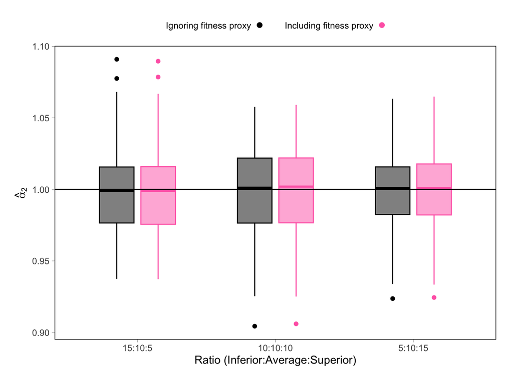

```r
plot.2.c.gamma.scale <- plot.sim.boxplot(sim.res.sc2, "0.5 1",
                             par.name = c("gamma_scale_sim",
                                          "gamma_scale_est", "gamma_scale_est_new"),
                             y.title = expression(hat(alpha)[2]),
                             x.title = "Ratio (Inferior:Average:Superior)")
plot.2.c.gamma.scale
```

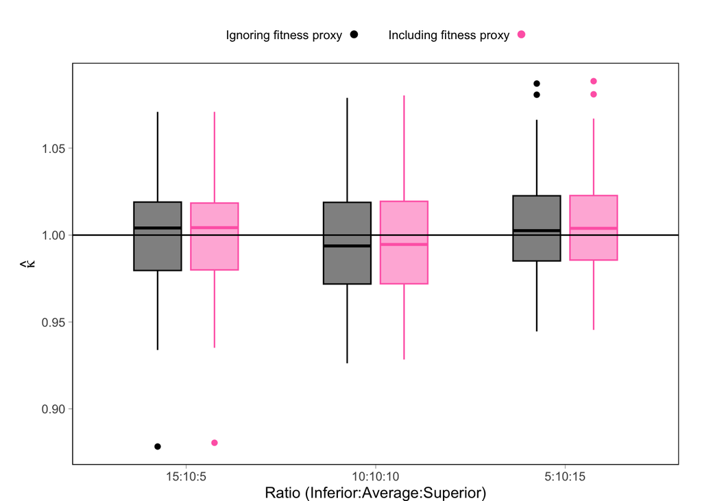

```r
plot.2.c.vonMises.kappa <- plot.sim.boxplot(sim.res.sc2, "0.5 1",
                             par.name = c("vonMises_kappa_sim",
                                          "vonMises_kappa_est", "vonMises_kappa_est_new"),
                             y.title = expression(hat(kappa)),
                             x.title = "Ratio (Inferior:Average:Superior)")
plot.2.c.vonMises.kappa
```

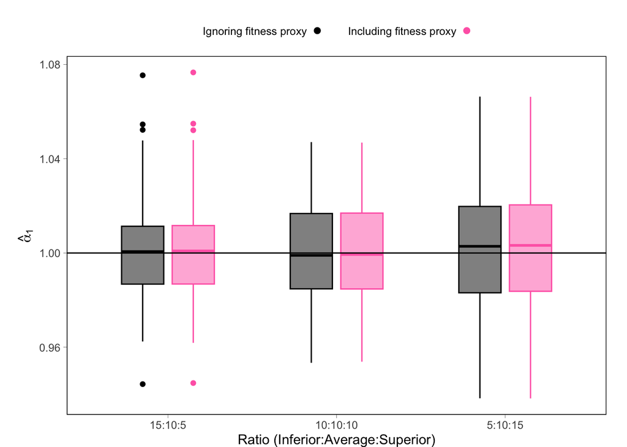

```r
# Scenarios
plot.2.d.gamma.shape <- plot.sim.boxplot(sim.res.sc2, "0 -1",
                             par.name = c("gamma_shape_sim",
                                          "gamma_shape_est", "gamma_shape_est_new"),
                             y.title = expression(hat(alpha)[1]),
                             x.title = "Ratio (Inferior:Average:Superior)")
plot.2.d.gamma.shape
```

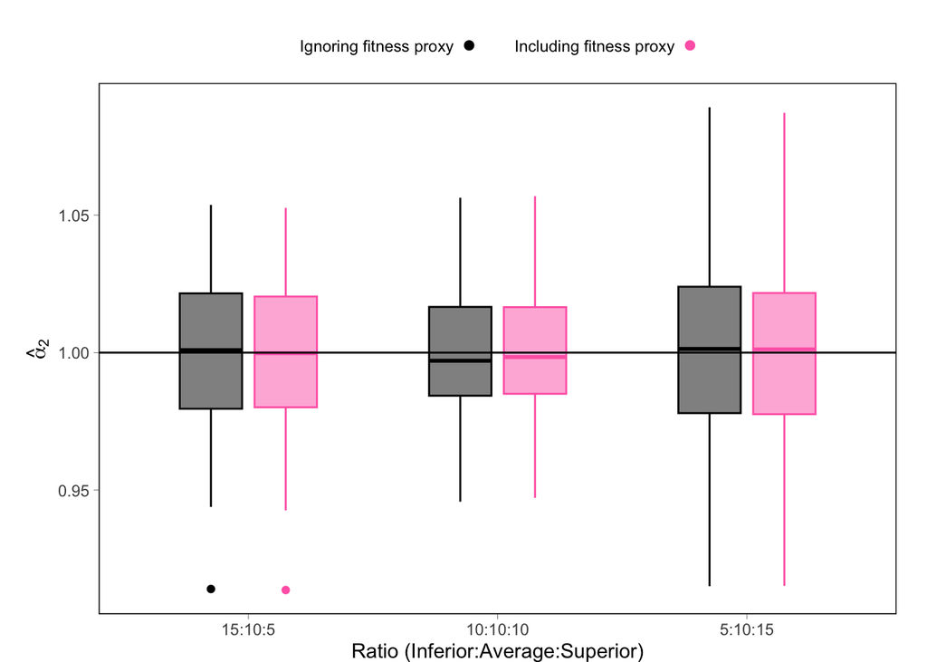

```r
plot.2.d.gamma.scale <- plot.sim.boxplot(sim.res.sc2, "0 -1",
                             par.name = c("gamma_scale_sim",
                                          "gamma_scale_est", "gamma_scale_est_new"),
                             y.title = expression(hat(alpha)[2]),
                             x.title = "Ratio (Inferior:Average:Superior)")
plot.2.d.gamma.scale
```

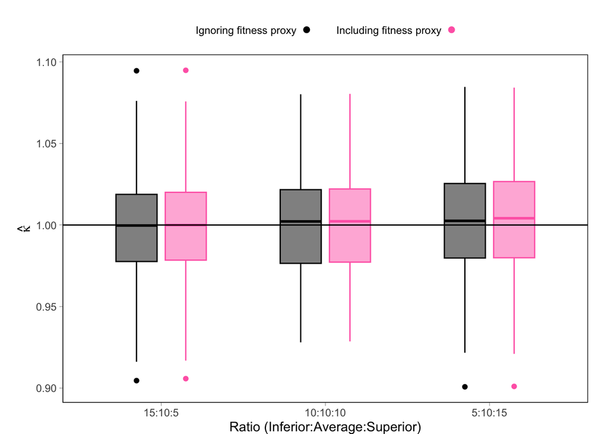

```r
plot.2.d.vonMises.kappa <- plot.sim.boxplot(sim.res.sc2, "0 -1",
                             par.name = c("vonMises_kappa_sim",
                                          "vonMises_kappa_est", "vonMises_kappa_est_new"),
                             y.title = expression(hat(kappa)),
                             x.title = "Ratio (Inferior:Average:Superior)")
plot.2.d.vonMises.kappa
```

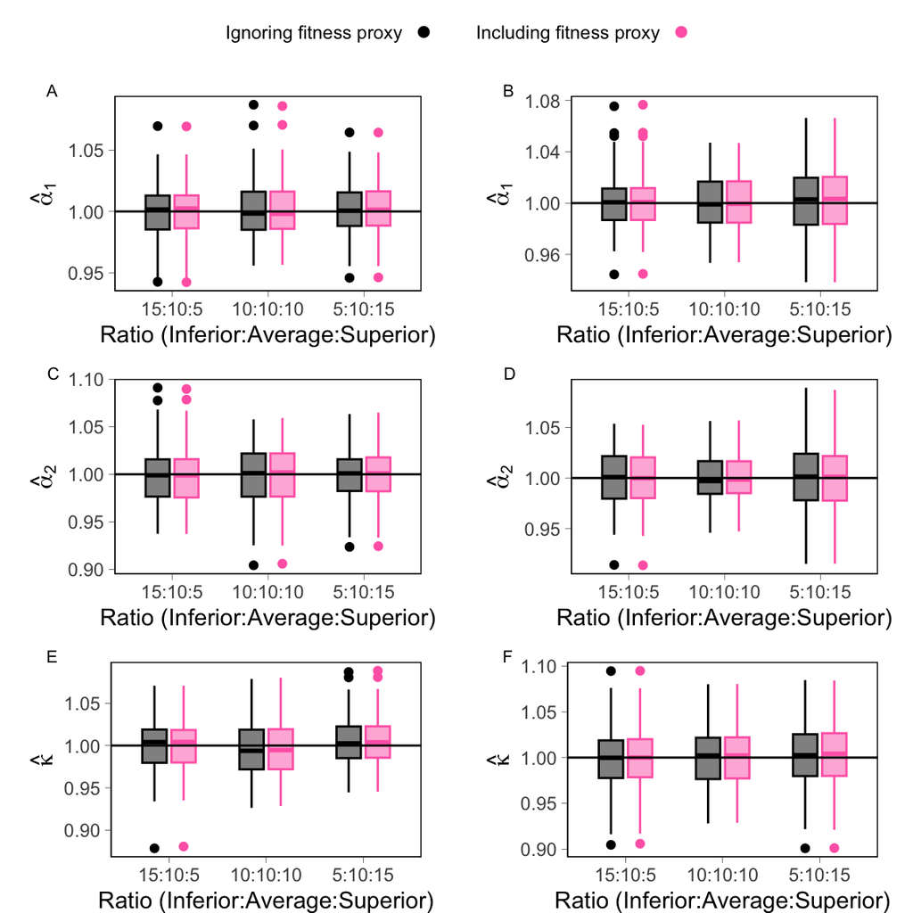

```r
ggarrange(legend.plot.rel,
  ggarrange(plot.2.c.gamma.shape, plot.2.d.gamma.shape,
            plot.2.c.gamma.scale, plot.2.d.gamma.scale,
            plot.2.c.vonMises.kappa, plot.2.d.vonMises.kappa,
            legend = "none",
          labels = c("A", "B", "C", "D", "E", "F"),
          label.x = rep(0.09, 6), label.y = rep(0.95, 6),
              font.label = list(size = 8, face="plain"),
          nrow = 3, ncol = 2), nrow=2, ncol=1, heights = c(0.07,0.93))
```

# Literature cited

Avgar, T., Lele, S. R., Keim, J. L., & Boyce, M. S. (2017). Relative selection strength: Quantifying effect size in habitat‐and step‐selection inference. Ecology and Evolution, 7, 5322-5330. https://doi.org/10.1002/ece3.3122

Fieberg, J., Signer, J., Smith, B., & Avgar, T. (2021). A ‘How to’ guide for interpreting parameters in habitat-selection analyses. Journal of Animal Ecology, 90, 1027-1043. https://doi.org/10.1111/1365-2656.13441